# airbnb-milano-analysis

costanzadeacutis

2023-02-01

# Setup

For the purpose of the analysis, I retain only those that can be defined as apartments in terms of property type.

I create factors from room_type variable, and I categorize it as factor variable together with f_municipio. I remove apartments that are categorized as outside, i.e. not in one of the 9 municipi, hence not directly comparable with the others (I assume that the apartments whose prices I am trying to predict are all in the city). I also retain only those apartments that can accommodate 2-6 guests, as the new apartments in question.

NB: Municipio - Given that the neighboorhoods are too many and too small, I regrouped them in “municipi”: this categorization comes from comune.milano.it. I then factorize them. Note: municipio_2_9 is area between Municipio 2 and Municipio 9, that could not be categorized in any of the two.

```r
data <- read.csv("airbnb_milano_cleaned.csv")

#check property types
table(data$property_type)
```

```
##
##                               Boat                          Camper/RV
##                                  1                                  3
##                    Casa particular                               Dome
##                                  6                                  2
##           Entire bed and breakfast                      Entire chalet
##                                  1                                  1
##                       Entire condo                     Entire cottage
##                               4728                                  1
##                 Entire guest suite                  Entire guesthouse
##                                 22                                  2
##                        Entire home                    Entire home/apt
##                                243                                  2
##                        Entire loft                       Entire place
##                                800                                 22
##                 Entire rental unit          Entire serviced apartment
##                               8908                                239
##                   Entire townhouse               Entire vacation home
##                                 18                                102
##                       Entire villa                             Island
##                                 19                                  1
##                       Private room  Private room in bed and breakfast
##                                 12                                122
##          Private room in camper/rv    Private room in casa particular
##                                  1                                 21
##               Private room in cave              Private room in condo
##                                  1                                903
##            Private room in cottage          Private room in farm stay
##                                  1                                  3
##        Private room in guest suite         Private room in guesthouse
##                                 15                                  4
##               Private room in home             Private room in hostel
##                                134                                 17
##               Private room in loft       Private room in nature lodge
##                                 80                                  1
##        Private room in rental unit Private room in serviced apartment
##                               2001                                 20
##          Private room in tiny home          Private room in townhouse
##                                  8                                 16
##      Private room in vacation home              Private room in villa
##                                 19                                 26
##                 Room in aparthotel          Room in bed and breakfast
##                                 15                                 13
##             Room in boutique hotel                     Room in hostel
##                                 65                                  6
##                      Room in hotel         Room in serviced apartment
##                                 39                                  5
##   Shared room in bed and breakfast               Shared room in condo
##                                  6                                 47
##                Shared room in home              Shared room in hostel
##                                  6                                 31
##                Shared room in loft         Shared room in rental unit
##                                  7                                138
##                          Tiny home
##                                 23
```

```r
#keep only apartments
#excluded private room cause not clear
data <- data %>% filter(property_type %in% c("Entire condo", "Entire home", "Entire home/apt", "Entire loft", "Entire place", "Entire rental unit", "Entire serviced apartment", "Entire vacation home", "Private room in condo", "Private room in home", "Private room in loft", "Private room in rental unit", "Private room in serviced apartment", "Private room in tiny home", "Private room in vacation home", "Room in serviced apartment", "Shared room in condo", "Shared room in home", "Shared room in loft", "Shared room in rental unit", "Tiny home"))

#check room types
table(data$room_type)
```

```
##
## Entire home/apt      Hotel room    Private room     Shared room
##           15067               5            3165             198
```

```r
#remove hotel room
data <- data %>% filter(room_type %in% c("Entire home/apt", "Private room", "Shared room"))
#factor
data <- data %>% mutate(f_room_type = factor(room_type))

#categorical variables
categoricals <- c("f_room_type", "f_municipio")

for (i in 1:length(categoricals)) {
  data %>%
    group_by(get(categoricals[i])) %>%
    summarise(mean_price = mean(price) ,  n=n()) %>%
    print
}
```

```
## # A tibble: 3 × 3
##   `get(categoricals[i])` mean_price     n
##   <fct>                       <dbl> <int>
## 1 Entire home/apt             183.  15067
## 2 Private room                165.   3165
## 3 Shared room                  73.2   198
## # A tibble: 11 × 3
##    `get(categoricals[i])` mean_price     n
##    <chr>                       <dbl> <int>
##  1 Municipio1                  217.   3535
##  2 Municipio2                  151.   2130
##  3 Municipio2-9                107.    255
##  4 Municipio3                  172.   2168
##  5 Municipio4                  232.   1930
##  6 Municipio5                  130.   1146
##  7 Municipio6                  156.   2758
##  8 Municipio7                  145.    873
##  9 Municipio8                  162.   1819
## 10 Municipio9                  197.   1812
## 11 Outside                      80.5     4
```

```r
#drop "outside" (not in the city center)
data <- data %>% filter(!(f_municipio %in% c("Outside")))

#number accommodates
data <- data %>% filter(n_accommodates %in% c(2,3,4,5,6))

#drop unused first column
drops <- c("X")
data <- data[ , !(names(data) %in% drops)]
```

## First look at the data

I have a dataset with 16833 observations and 77 variables. Some of these variables have some/many missing values: review_scores_rate, p_host_acceptance_rate, p_host_response_rate, n_days_since, n_bathrooms, f_bathrooms_type, n_beds, n_bedrooms, n_reviews_per_month

```r
glimpse(data)
```

```
## Rows: 16,833
## Columns: 77
## $ name                          <chr> "\" Characteristic Milanese flat\"", "Ex…
## $ id                            <dbl> 23986, 392891, 256390, 393671, 394443, 3…
## $ price                         <dbl> 150, 300, 135, 125, 150, 109, 60, 80, 93…
## $ neighbourhood_cleansed        <chr> "NAVIGLI", "BUENOS AIRES - VENEZIA", "BU…
## $ room_type                     <chr> "Entire home/apt", "Entire home/apt", "E…
## $ property_type                 <chr> "Entire rental unit", "Entire condo", "E…
## $ review_scores_rating          <dbl> 4.57, 5.00, 4.88, 5.00, 4.94, 4.75, 4.57…
## $ p_host_acceptance_rate        <int> 41, 71, 38, 0, 48, NA, 0, 24, 48, 53, 0,…
## $ p_host_response_rate          <int> 100, 100, 100, NA, 100, NA, 100, 100, 10…
## $ n_days_since                  <int> 3893, 100, 3537, 417, 3848, 2804, 3972, …
## $ f_bathrooms_type              <chr> NA, NA, NA, NA, NA, NA, NA, NA, NA, NA, …
## $ f_municipio                   <chr> "Municipio6", "Municipio3", "Municipio3"…
## $ n_accommodates                <int> 4, 4, 2, 2, 4, 4, 4, 4, 4, 4, 2, 5, 2, 2…
```

[output cut: 64 more lines]

```r
skim(data)
```

Data summary

| Name | data |
| --- | --- |
| Number of rows | 16833 |
| Number of columns | 77 |
| _______________________ |  |
| Column type frequency: |  |
| character | 6 |
| factor | 1 |
| numeric | 70 |
| ________________________ |  |
| Group variables | None |

**Variable type: character**

| skim_variable | n_missing | complete_rate | min | max | empty | n_unique | whitespace |
| --- | --- | --- | --- | --- | --- | --- | --- |
| name | 0 | 1.00 | 0 | 243 | 7 | 16567 | 0 |
| neighbourhood_cleansed | 0 | 1.00 | 4 | 28 | 0 | 85 | 0 |
| room_type | 0 | 1.00 | 11 | 15 | 0 | 3 | 0 |
| property_type | 0 | 1.00 | 9 | 34 | 0 | 20 | 0 |
| f_bathrooms_type | 14947 | 0.11 | 6 | 7 | 0 | 2 | 0 |
| f_municipio | 0 | 1.00 | 10 | 12 | 0 | 10 | 0 |

**Variable type: factor**

| skim_variable | n_missing | complete_rate | ordered | n_unique | top_counts |
| --- | --- | --- | --- | --- | --- |
| f_room_type | 0 | 1 | FALSE | 3 | Ent: 14523, Pri: 2232, Sha: 78 |

**Variable type: numeric**

| skim_variable | n_missing | complete_rate | mean | sd | p0 | p25 | p50 | p75 | p100 | hist |
| --- | --- | --- | --- | --- | --- | --- | --- | --- | --- | --- |
| id | 0 | 1.00 | 1.83712e+17 | 3.015439e+17 | 23986.00 | 19206670.00 | 38457943.00 | 5.772251e+17 | 7.861332e+17 | ▇▁▁▁▂ |
| price | 0 | 1.00 | 1.79780e+02 | 1.355240e+03 | 9.00 | 71.00 | 100.00 | 1.500000e+02 | 9.018000e+04 | ▇▁▁▁▁ |
| review_scores_rating | 3066 | 0.82 | 4.61000e+00 | 6.900000e-01 | 0.00 | 4.54 | 4.81 | 5.000000e+00 | 5.000000e+00 | ▁▁▁▁▇ |
| p_host_acceptance_rate | 3252 | 0.81 | 8.21600e+01 | 2.929000e+01 | 0.00 | 75.00 | 99.00 | 1.000000e+02 | 1.000000e+02 | ▁▁▁▁▇ |
| p_host_response_rate | 4342 | 0.74 | 9.37000e+01 | 1.763000e+01 | 0.00 | 98.00 | 100.00 | 1.000000e+02 | 1.000000e+02 | ▁▁▁▁▇ |
| n_days_since | 3066 | 0.82 | 1.19833e+03 | 9.954400e+02 | 1.00 | 233.00 | 1130.00 | 1.926000e+03 | 4.384000e+03 | ▇▅▃▂▁ |
| n_accommodates | 0 | 1.00 | 3.08000e+00 | 1.170000e+00 | 2.00 | 2.00 | 3.00 | 4.000000e+00 | 6.000000e+00 | ▇▂▅▁▁ |
| n_bathrooms | 2 | 1.00 | 1.11000e+00 | 3.300000e-01 | 0.00 | 1.00 | 1.00 | 1.000000e+00 | 6.000000e+00 | ▇▁▁▁▁ |
| n_number_of_reviews | 0 | 1.00 | 3.13800e+01 | 6.973000e+01 | 0.00 | 1.00 | 7.00 | 2.800000e+01 | 1.059000e+03 | ▇▁▁▁▁ |
| n_reviews_per_month | 3066 | 0.82 | 1.33000e+00 | 1.760000e+00 | 0.01 | 0.18 | 0.63 | 1.780000e+00 | 1.491000e+01 | ▇▁▁▁▁ |
| n_minimum_nights | 0 | 1.00 | 4.65000e+00 | 2.478000e+01 | 1.00 | 1.00 | 2.00 | 3.000000e+00 | 1.125000e+03 | ▇▁▁▁▁ |
| n_beds | 192 | 0.99 | 1.76000e+00 | 9.400000e-01 | 1.00 | 1.00 | 2.00 | 2.000000e+00 | 1.300000e+01 | ▇▁▁▁▁ |
| n_bedrooms | 1278 | 0.92 | 1.22000e+00 | 4.800000e-01 | 1.00 | 1.00 | 1.00 | 1.000000e+00 | 5.000000e+00 | ▇▂▁▁▁ |
| d_bathroomessentials | 0 | 1.00 | 8.50000e-01 | 3.600000e-01 | 0.00 | 1.00 | 1.00 | 1.000000e+00 | 1.000000e+00 | ▂▁▁▁▇ |
| d_fridge | 0 | 1.00 | 6.90000e-01 | 4.600000e-01 | 0.00 | 0.00 | 1.00 | 1.000000e+00 | 1.000000e+00 | ▃▁▁▁▇ |
| d_stove | 0 | 1.00 | 5.20000e-01 | 5.000000e-01 | 0.00 | 0.00 | 1.00 | 1.000000e+00 | 1.000000e+00 | ▇▁▁▁▇ |
| d_oven | 0 | 1.00 | 4.50000e-01 | 5.000000e-01 | 0.00 | 0.00 | 0.00 | 1.000000e+00 | 1.000000e+00 | ▇▁▁▁▆ |
| d_tv | 0 | 1.00 | 2.50000e-01 | 4.400000e-01 | 0.00 | 0.00 | 0.00 | 1.000000e+00 | 1.000000e+00 | ▇▁▁▁▃ |
| d_soundsystem | 0 | 1.00 | 3.00000e-02 | 1.800000e-01 | 0.00 | 0.00 | 0.00 | 0.000000e+00 | 1.000000e+00 | ▇▁▁▁▁ |
| d_smarttv | 0 | 1.00 | 1.00000e-01 | 3.000000e-01 | 0.00 | 0.00 | 0.00 | 0.000000e+00 | 1.000000e+00 | ▇▁▁▁▁ |
| d_ac | 0 | 1.00 | 8.50000e-01 | 3.600000e-01 | 0.00 | 1.00 | 1.00 | 1.000000e+00 | 1.000000e+00 | ▂▁▁▁▇ |
| d_wardrobe | 0 | 1.00 | 7.80000e-01 | 4.100000e-01 | 0.00 | 1.00 | 1.00 | 1.000000e+00 | 1.000000e+00 | ▂▁▁▁▇ |
| d_babykit | 0 | 1.00 | 1.60000e-01 | 3.600000e-01 | 0.00 | 0.00 | 0.00 | 0.000000e+00 | 1.000000e+00 | ▇▁▁▁▂ |
| d_kitchenamenities | 0 | 1.00 | 9.60000e-01 | 1.900000e-01 | 0.00 | 1.00 | 1.00 | 1.000000e+00 | 1.000000e+00 | ▁▁▁▁▇ |
| d_outdoorfurniture | 0 | 1.00 | 1.00000e-01 | 3.000000e-01 | 0.00 | 0.00 | 0.00 | 0.000000e+00 | 1.000000e+00 | ▇▁▁▁▁ |
| d_bathtub | 0 | 1.00 | 1.10000e-01 | 3.100000e-01 | 0.00 | 0.00 | 0.00 | 0.000000e+00 | 1.000000e+00 | ▇▁▁▁▁ |
| d_bedroomessentials | 0 | 1.00 | 6.00000e-01 | 4.900000e-01 | 0.00 | 0.00 | 1.00 | 1.000000e+00 | 1.000000e+00 | ▅▁▁▁▇ |
| d_bidet | 0 | 1.00 | 3.70000e-01 | 4.800000e-01 | 0.00 | 0.00 | 0.00 | 1.000000e+00 | 1.000000e+00 | ▇▁▁▁▅ |
| d_bikes | 0 | 1.00 | 1.00000e-02 | 1.000000e-01 | 0.00 | 0.00 | 0.00 | 0.000000e+00 | 1.000000e+00 | ▇▁▁▁▁ |
| d_games | 0 | 1.00 | 3.00000e-02 | 1.600000e-01 | 0.00 | 0.00 | 0.00 | 0.000000e+00 | 1.000000e+00 | ▇▁▁▁▁ |
| d_readingmaterial | 0 | 1.00 | 1.60000e-01 | 3.700000e-01 | 0.00 | 0.00 | 0.00 | 0.000000e+00 | 1.000000e+00 | ▇▁▁▁▂ |
| d_breakfast | 0 | 1.00 | 1.30000e-01 | 3.300000e-01 | 0.00 | 0.00 | 0.00 | 0.000000e+00 | 1.000000e+00 | ▇▁▁▁▁ |
| d_buildingstaff | 0 | 1.00 | 2.00000e-02 | 1.500000e-01 | 0.00 | 0.00 | 0.00 | 0.000000e+00 | 1.000000e+00 | ▇▁▁▁▁ |
| d_specialview | 0 | 1.00 | 1.90000e-01 | 3.900000e-01 | 0.00 | 0.00 | 0.00 | 0.000000e+00 | 1.000000e+00 | ▇▁▁▁▂ |
| d_security | 0 | 1.00 | 4.80000e-01 | 5.000000e-01 | 0.00 | 0.00 | 0.00 | 1.000000e+00 | 1.000000e+00 | ▇▁▁▁▇ |
| d_heating | 0 | 1.00 | 9.20000e-01 | 2.700000e-01 | 0.00 | 1.00 | 1.00 | 1.000000e+00 | 1.000000e+00 | ▁▁▁▁▇ |
| d_table | 0 | 1.00 | 3.20000e-01 | 4.700000e-01 | 0.00 | 0.00 | 0.00 | 1.000000e+00 | 1.000000e+00 | ▇▁▁▁▃ |
| d_toysforchildren | 0 | 1.00 | 6.00000e-02 | 2.300000e-01 | 0.00 | 0.00 | 0.00 | 0.000000e+00 | 1.000000e+00 | ▇▁▁▁▁ |
| d_cleaningavailableduringstay | 0 | 1.00 | 5.00000e-02 | 2.100000e-01 | 0.00 | 0.00 | 0.00 | 0.000000e+00 | 1.000000e+00 | ▇▁▁▁▁ |
| d_cleaningproducts | 0 | 1.00 | 3.00000e-01 | 4.600000e-01 | 0.00 | 0.00 | 0.00 | 1.000000e+00 | 1.000000e+00 | ▇▁▁▁▃ |
| d_washingmachine | 0 | 1.00 | 8.60000e-01 | 3.500000e-01 | 0.00 | 1.00 | 1.00 | 1.000000e+00 | 1.000000e+00 | ▂▁▁▁▇ |
| d_dryer | 0 | 1.00 | 8.60000e-01 | 3.400000e-01 | 0.00 | 1.00 | 1.00 | 1.000000e+00 | 1.000000e+00 | ▁▁▁▁▇ |
| d_elevator | 0 | 1.00 | 5.00000e-01 | 5.000000e-01 | 0.00 | 0.00 | 1.00 | 1.000000e+00 | 1.000000e+00 | ▇▁▁▁▇ |
| d_essentials | 0 | 1.00 | 0.00000e+00 | 1.000000e-02 | 0.00 | 0.00 | 0.00 | 0.000000e+00 | 1.000000e+00 | ▇▁▁▁▁ |
| d_ethernetconnection | 0 | 1.00 | 9.00000e-02 | 2.900000e-01 | 0.00 | 0.00 | 0.00 | 0.000000e+00 | 1.000000e+00 | ▇▁▁▁▁ |
| d_evcharger | 0 | 1.00 | 2.00000e-02 | 1.300000e-01 | 0.00 | 0.00 | 0.00 | 0.000000e+00 | 1.000000e+00 | ▇▁▁▁▁ |
| d_exerciseequip | 0 | 1.00 | 0.00000e+00 | 0.000000e+00 | 0.00 | 0.00 | 0.00 | 0.000000e+00 | 0.000000e+00 | ▁▁▇▁▁ |
| d_wifi | 0 | 1.00 | 9.20000e-01 | 2.700000e-01 | 0.00 | 1.00 | 1.00 | 1.000000e+00 | 1.000000e+00 | ▁▁▁▁▇ |
| d_reservedparking | 0 | 1.00 | 3.40000e-01 | 4.700000e-01 | 0.00 | 0.00 | 0.00 | 1.000000e+00 | 1.000000e+00 | ▇▁▁▁▅ |
| d_unreservedparking | 0 | 1.00 | 2.40000e-01 | 4.300000e-01 | 0.00 | 0.00 | 0.00 | 0.000000e+00 | 1.000000e+00 | ▇▁▁▁▂ |
| d_gym | 0 | 1.00 | 2.00000e-02 | 1.300000e-01 | 0.00 | 0.00 | 0.00 | 0.000000e+00 | 1.000000e+00 | ▇▁▁▁▁ |
| d_hottub | 0 | 1.00 | 3.00000e-02 | 1.600000e-01 | 0.00 | 0.00 | 0.00 | 0.000000e+00 | 1.000000e+00 | ▇▁▁▁▁ |
| d_iron | 0 | 1.00 | 7.10000e-01 | 4.500000e-01 | 0.00 | 0.00 | 1.00 | 1.000000e+00 | 1.000000e+00 | ▃▁▁▁▇ |
| d_keypad | 0 | 1.00 | 2.00000e-01 | 4.000000e-01 | 0.00 | 0.00 | 0.00 | 0.000000e+00 | 1.000000e+00 | ▇▁▁▁▂ |
| d_pool | 0 | 1.00 | 1.00000e-02 | 1.000000e-01 | 0.00 | 0.00 | 0.00 | 0.000000e+00 | 1.000000e+00 | ▇▁▁▁▁ |
| d_externallaudry | 0 | 1.00 | 0.00000e+00 | 0.000000e+00 | 0.00 | 0.00 | 0.00 | 0.000000e+00 | 0.000000e+00 | ▁▁▇▁▁ |
| d_luggagedropoffallowed | 0 | 1.00 | 1.70000e-01 | 3.800000e-01 | 0.00 | 0.00 | 0.00 | 0.000000e+00 | 1.000000e+00 | ▇▁▁▁▂ |
| d_windowsamenities | 0 | 1.00 | 2.40000e-01 | 4.300000e-01 | 0.00 | 0.00 | 0.00 | 0.000000e+00 | 1.000000e+00 | ▇▁▁▁▂ |
| d_patioorbalcony | 0 | 1.00 | 2.90000e-01 | 4.600000e-01 | 0.00 | 0.00 | 0.00 | 1.000000e+00 | 1.000000e+00 | ▇▁▁▁▃ |
| d_petsallowed | 0 | 1.00 | 2.20000e-01 | 4.100000e-01 | 0.00 | 0.00 | 0.00 | 0.000000e+00 | 1.000000e+00 | ▇▁▁▁▂ |
| d_piano | 0 | 1.00 | 1.00000e-02 | 7.000000e-02 | 0.00 | 0.00 | 0.00 | 0.000000e+00 | 1.000000e+00 | ▇▁▁▁▁ |
| d_privateentrance | 0 | 1.00 | 2.30000e-01 | 4.200000e-01 | 0.00 | 0.00 | 0.00 | 0.000000e+00 | 1.000000e+00 | ▇▁▁▁▂ |
| d_privatelivingroom | 0 | 1.00 | 1.00000e-02 | 1.100000e-01 | 0.00 | 0.00 | 0.00 | 0.000000e+00 | 1.000000e+00 | ▇▁▁▁▁ |
| d_sauna | 0 | 1.00 | 0.00000e+00 | 3.000000e-02 | 0.00 | 0.00 | 0.00 | 0.000000e+00 | 1.000000e+00 | ▇▁▁▁▁ |
| d_rooftop | 0 | 1.00 | 0.00000e+00 | 1.000000e-02 | 0.00 | 0.00 | 0.00 | 0.000000e+00 | 1.000000e+00 | ▇▁▁▁▁ |
| d_smokingallowed | 0 | 1.00 | 0.00000e+00 | 1.000000e-02 | 0.00 | 0.00 | 0.00 | 0.000000e+00 | 1.000000e+00 | ▇▁▁▁▁ |
| d_suitableforevents | 0 | 1.00 | 0.00000e+00 | 1.000000e-02 | 0.00 | 0.00 | 0.00 | 0.000000e+00 | 1.000000e+00 | ▇▁▁▁▁ |
| d_firepit | 0 | 1.00 | 0.00000e+00 | 7.000000e-02 | 0.00 | 0.00 | 0.00 | 0.000000e+00 | 1.000000e+00 | ▇▁▁▁▁ |
| d_exerciseequipm | 0 | 1.00 | 2.00000e-02 | 1.400000e-01 | 0.00 | 0.00 | 0.00 | 0.000000e+00 | 1.000000e+00 | ▇▁▁▁▁ |
| d_externallaundry | 0 | 1.00 | 1.00000e-01 | 3.000000e-01 | 0.00 | 0.00 | 0.00 | 0.000000e+00 | 1.000000e+00 | ▇▁▁▁▁ |

```r
# where do we have missing variables now?
to_filter <- sapply(data, function(x) sum(is.na(x)))
to_filter[to_filter > 0]
```

```
##   review_scores_rating p_host_acceptance_rate   p_host_response_rate
##                   3066                   3252                   4342
##           n_days_since       f_bathrooms_type            n_bathrooms
##                   3066                  14947                      2
##    n_reviews_per_month                 n_beds             n_bedrooms
##                   3066                    192                   1278
```

## Further cleaning - Deal with NAs

There are different ways of dealing with missing values: 1. remove when it is the target variable 2. remove those variables that have too many NAs and the variable is not that important for the analysis 3. input values (for beds, assume that the number is the same as the number of accommodates) 4. replace with median and flag when there are many but the variable is important for the analysis

```r
# 1. drop NA if target variable
data <- data %>%
  drop_na(price)

# 2. remove when too many
to_drop <- c("f_bathrooms_type", "p_host_response_rate", "p_host_acceptance_rate", "property_type")
data <- data %>%
  select(-one_of(to_drop))

# 3. imput when few, not that important
#bathrooms
#beds
data <- data %>%
  mutate(
    n_bathrooms =  ifelse(is.na(n_bathrooms), median(n_bathrooms, na.rm = T), n_bathrooms),
    n_beds = ifelse(is.na(n_beds), n_accommodates, n_beds)) #assume n_beds=n_accommodates

to_filter <- sapply(data, function(x) sum(is.na(x)))
to_filter[to_filter > 0]
```

```
## review_scores_rating         n_days_since  n_reviews_per_month
##                 3066                 3066                 3066
##           n_bedrooms
##                 1278
```

```r
# 4. Replace missing variables + add flags
#reviews
#bedrooms
#days since
data <- data %>%
  mutate(flag_bedrooms=ifelse(is.na(n_bedrooms),1, 0),
    n_bedrooms =  ifelse(is.na(n_bedrooms), median(n_bedrooms, na.rm = T), n_bedrooms),
    flag_days_since=ifelse(is.na(n_days_since),1, 0),
    n_days_since =  ifelse(is.na(n_days_since), median(n_days_since, na.rm = T), n_days_since),
    flag_review_scores_rating=ifelse(is.na(review_scores_rating),1, 0),
    review_scores_rating =  ifelse(is.na(review_scores_rating), median(review_scores_rating, na.rm = T), review_scores_rating),
    flag_reviews_per_month=ifelse(is.na(n_reviews_per_month),1, 0),
    n_reviews_per_month =  ifelse(is.na(n_reviews_per_month), median(n_reviews_per_month, na.rm = T), n_reviews_per_month)
          )
table(data$flag_days_since)
```

```
##
##     0     1
## 13767  3066
```

## Create variables polynomials

- measuring the time since: squared, cubic, logs
- squared accommodates
- log ratings

```r
data <- data %>%
  mutate(
    ln_days_since = log(n_days_since+1),
    ln_days_since2 = log(n_days_since+1)^2,
    ln_days_since3 = log(n_days_since+1)^3 ,
    n_days_since2=n_days_since^2,
    n_days_since3=n_days_since^3,
    n_accommodates2 = n_accommodates^2,
    ln_review_scores_rating = log(review_scores_rating),
    ln_days_since=ifelse(is.na(ln_days_since),0, ln_days_since),
    ln_days_since2=ifelse(is.na(ln_days_since2),0, ln_days_since2),
    ln_days_since3=ifelse(is.na(ln_days_since3),0, ln_days_since3),
  )
```

# Descriptive analysis

## Prices

```r
#Prices
summary(data$price)
```

```
##    Min. 1st Qu.  Median    Mean 3rd Qu.    Max.
##     9.0    71.0   100.0   179.8   150.0 90180.0
```

```r
describe(data$price)
```

| vars | n | mean | sd | median | trimmed | mad | min | max | range | skew | kurtosis | se |
| --- | --- | --- | --- | --- | --- | --- | --- | --- | --- | --- | --- | --- |
| 1 | 1.68e+04 | 180 | 1.36e+03 | 100 | 112 | 51.9 | 9 | 9.02e+04 | 9.02e+04 | 53.8 | 3.39e+03 | 10.4 |

```r
#drop very weird prices above 1500 and below 20
data <- data %>% filter(price <= 1500,
                        price > 20)

data <- data %>%
  mutate(ln_price = log(price))

#How is the average price changing by `room_type` and the `municipio`?
data %>%
  group_by(f_municipio, f_room_type) %>%
  dplyr::summarize(mean_price = mean(price, na.rm=TRUE))
```

```
## # A tibble: 30 × 3
## # Groups:   f_municipio [10]
##    f_municipio  f_room_type     mean_price
##    <chr>        <fct>                <dbl>
##  1 Municipio1   Entire home/apt      187.
##  2 Municipio1   Private room         125.
##  3 Municipio1   Shared room           63.2
##  4 Municipio2   Entire home/apt      114.
##  5 Municipio2   Private room          76.2
##  6 Municipio2   Shared room          114.
##  7 Municipio2-9 Entire home/apt      113.
##  8 Municipio2-9 Private room          82
##  9 Municipio2-9 Shared room           43
## 10 Municipio3   Entire home/apt      131.
## # … with 20 more rows
```

```r
Hmisc::describe(data$price)
```

```
## data$price
##        n  missing distinct     Info     Mean      Gmd      .05      .10
##    16700        0      523        1    132.6    95.28       44       52
##      .25      .50      .75      .90      .95
##       71      100      150      240      307
##
## lowest :   21   22   23   24   25, highest: 1300 1304 1350 1400 1500
```

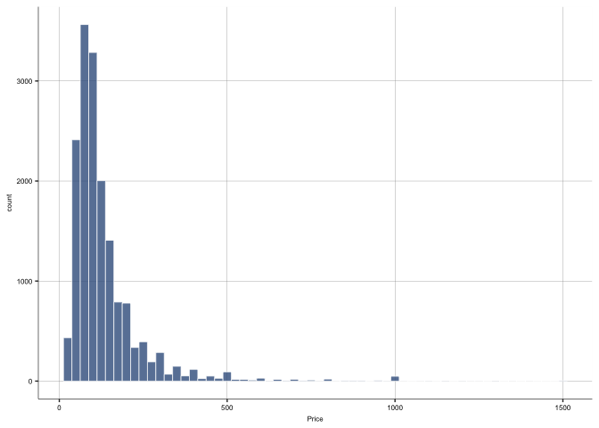

```r
# Histograms
Airbnb_price <- ggplot(data, aes(price)) +
  geom_histogram(binwidth = 25, fill = color[1], color = color.outline, alpha = 0.8, size = 0.25) +
  ylab("count") +
  xlab("Price") +
  theme_bg()
Airbnb_price
```

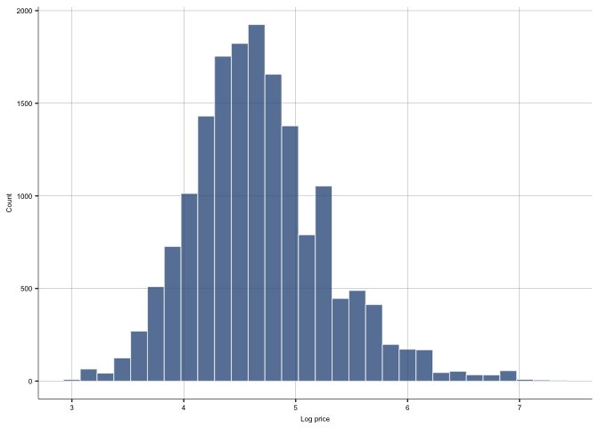

```r
Airbnb_lnprice <- ggplot(data, aes(ln_price)) +
  geom_histogram(binwidth = 0.15, fill = color[1], color = color.outline, alpha = 0.8, size = 0.25) +
  ylab("Count") +
  xlab("Log price") +
  theme_bg()
Airbnb_lnprice
```

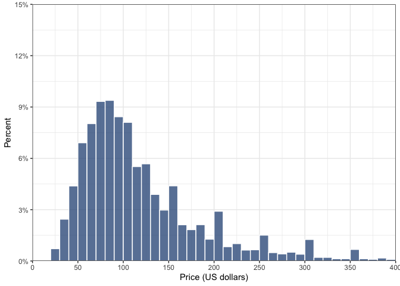

```r
# Look even closer, consider only prices below 400
datau <- subset(data, price<400)

# Histograms
# price
Airbnb_price_percent <- ggplot(data=datau, aes(x=price)) +
  geom_histogram_da(type="percent", binwidth = 10) +
  labs(x = "Price (US dollars)",y = "Percent")+
  scale_y_continuous(expand = c(0.00,0.00),limits=c(0, 0.15), breaks = seq(0, 0.15, by = 0.03), labels = scales::percent_format(1)) +
    scale_x_continuous(expand = c(0.00,0.00),limits=c(0,400), breaks = seq(0,400, 50)) +
  theme_bw()
Airbnb_price_percent
```

```r
save_fig("Airbnb-price-percent", output, "small")
```

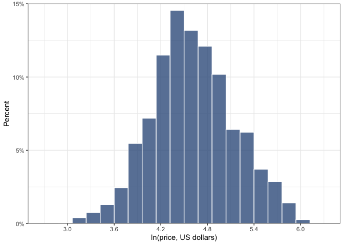

```r
# lnprice
Airbnb_price_percent<- ggplot(data=datau, aes(x=ln_price)) +
  geom_histogram_da(type="percent", binwidth = 0.18) +
  #  geom_histogram(aes(y = (..count..)/sum(..count..)), binwidth = 0.18,
  #               color = color.outline, fill = color[1], size = 0.25, alpha = 0.8,  show.legend=F,  na.rm=TRUE) +
  coord_cartesian(xlim = c(2.5, 6.5)) +
  scale_y_continuous(expand = c(0.00,0.00),limits=c(0, 0.15), breaks = seq(0, 0.15, by = 0.05), labels = scales::percent_format(5L)) +
  scale_x_continuous(expand = c(0.00,0.01),breaks = seq(2.4,6.6, 0.6)) +
  labs(x = "ln(price, US dollars)",y = "Percent")+
  theme_bw()
Airbnb_price_percent
```

```r
save_fig("Airbnb-price-percent", output, "small")
```

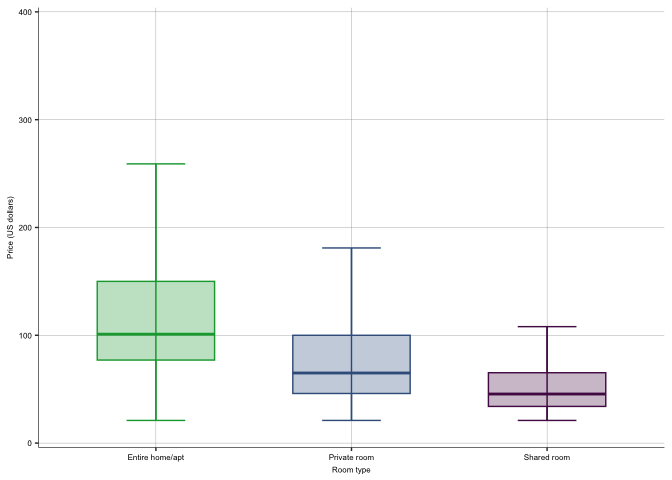

```r
## Boxplot of price by room type
Airbnb_room_type <- ggplot(data = datau, aes(x = f_room_type, y = price)) +
  stat_boxplot(aes(group = f_room_type), geom = "errorbar", width = 0.3,
               color = c(color[2],color[1], color[3]), size = 0.5, na.rm=T)+
  geom_boxplot(aes(group = f_room_type),
               color = c(color[2],color[1], color[3]), fill = c(color[2],color[1], color[3]),
               size = 0.5, width = 0.6, alpha = 0.3, na.rm=T, outlier.shape = NA) +
  scale_y_continuous(expand = c(0.01,0.01),limits = c(0,400), breaks = seq(0,400,100)) +
  labs(x = "Room type",y = "Price (US dollars)")+
  theme_bg()
Airbnb_room_type
```

```r
save_fig("Airbnb_room_type", output, "small")
```

## Number of accommodates

It can be seen from both the graph and the table that the mean price increases as the number of accommodates increase, as expected.

```r
## n_accommodates: look at distribution

data %>%
  group_by(n_accommodates) %>%
  summarise(mean_price = mean(price), min_price= min(price), max_price = max(price), n = n())
```

| n_accommodates | mean_price | min_price | max_price | n |
| --- | --- | --- | --- | --- |
| 2 | 113 | 21 | 1.5e+03 | 7678 |
| 3 | 127 | 21 | 1.3e+03 | 2349 |
| 4 | 146 | 22 | 1.5e+03 | 5119 |
| 5 | 176 | 28 | 1.4e+03 | 725 |
| 6 | 212 | 39 | 1.5e+03 | 829 |

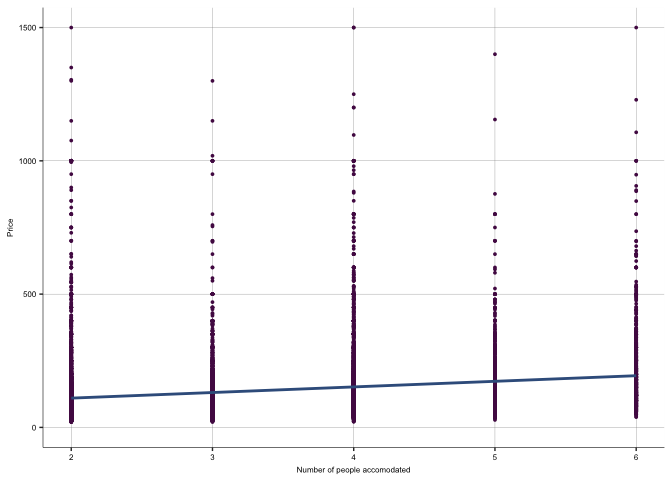

```r
Airbnb_n_accommodates <- ggplot(data = data, aes(x=n_accommodates, y=price)) +
  geom_point(size=1, colour=color[3], shape=16)+
  ylim(0,1500)+
  xlim(2,6)+
  labs(x="Number of people accomodated",y="Price")+
  geom_smooth(method="lm", colour=color[1], se=FALSE)+
  theme_bg()
Airbnb_n_accommodates
```

## Number of beds and bathrooms

For bathrooms, where the value is 0, it probably means that the bathroom is outside the private or shared room, thus I impute that there is at least 1. Also those 0.5, I assume that they are like 1 bathroom. The mean price increases as the number of bathrooms increases.

```r
## Beds
data %>%
  group_by(n_beds) %>%
  summarise(mean_price = mean(price), min_price= min(price), max_price = max(price), n = n())
```

| n_beds | mean_price | min_price | max_price | n |
| --- | --- | --- | --- | --- |
| 1 | 119 | 21 | 1.5e+03 | 7839 |
| 2 | 132 | 21 | 1.5e+03 | 6181 |
| 3 | 165 | 24 | 1.4e+03 | 1726 |
| 4 | 187 | 25 | 1.5e+03 | 702 |
| 5 | 198 | 28 | 1e+03 | 160 |
| 6 | 198 | 50 | 643 | 78 |
| 7 | 336 | 66 | 700 | 6 |
| 8 | 106 | 63 | 150 | 2 |
| 9 | 135 | 80 | 190 | 2 |
| 10 | 500 | 500 | 500 | 1 |
| 11 | 54 | 54 | 54 | 1 |
| 12 | 110 | 110 | 110 | 1 |
| 13 | 156 | 156 | 156 | 1 |

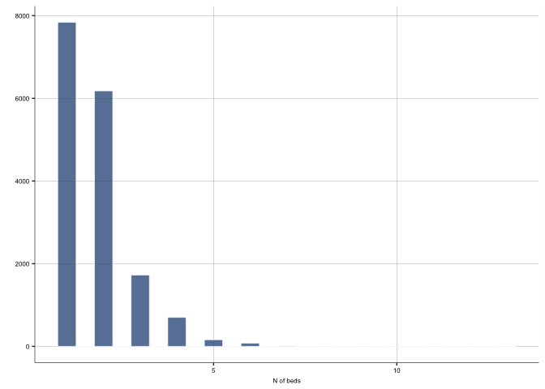

```r
# maybe best is to have log beds
data <- data %>%
  mutate(ln_beds = log(n_beds))

ggplot(data, aes(n_beds)) +
  geom_histogram(binwidth = 0.5, fill = color[1], color = color.outline, alpha = 0.8, size = 0.25) +
  ylab("") +
  xlab("N of beds") +
  theme_bg()
```

```r
## bathrooms
data %>%
  group_by(n_bathrooms) %>%
  summarise(mean_price = mean(price), n = n())
```

| n_bathrooms | mean_price | n |
| --- | --- | --- |
| 0 | 103 | 7 |
| 0.5 | 67.5 | 8 |
| 1 | 122 | 14954 |
| 2 | 216 | 1642 |
| 3 | 383 | 81 |
| 4 | 486 | 8 |

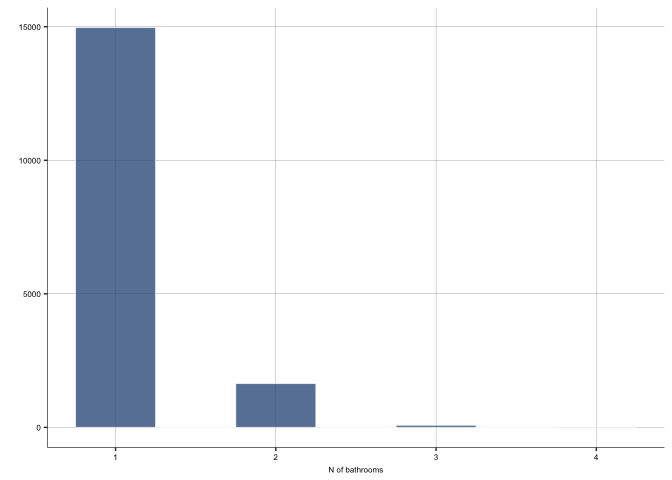

```r
data <- data %>%
  mutate(n_bathrooms =  ifelse(n_bathrooms==0.0, 1, n_bathrooms),
         n_bathrooms =  ifelse(n_bathrooms==0.5, 1, n_bathrooms))

ggplot(data, aes(n_bathrooms)) +
  geom_histogram(binwidth = 0.5, fill = color[1], color = color.outline, alpha = 0.8, size = 0.25) +
  ylab("") +
  xlab("N of bathrooms") +
  theme_bg()
```

```r
data %>%
  group_by(n_bathrooms) %>%
  summarise(mean_price = mean(price), n = n())
```

| n_bathrooms | mean_price | n |
| --- | --- | --- |
| 1 | 122 | 14969 |
| 2 | 216 | 1642 |
| 3 | 383 | 81 |
| 4 | 486 | 8 |

## Number of reviews

For better visualization, I consider only those apartments that have less then 100 reviews (those with more are not frequent). The distribution is highly right-skewed. I also create a factor variable for 3 categories: apartments with either none, 1-50, or 51+ reviews. Apartments with 0 reviews appear to have higher mean prices.

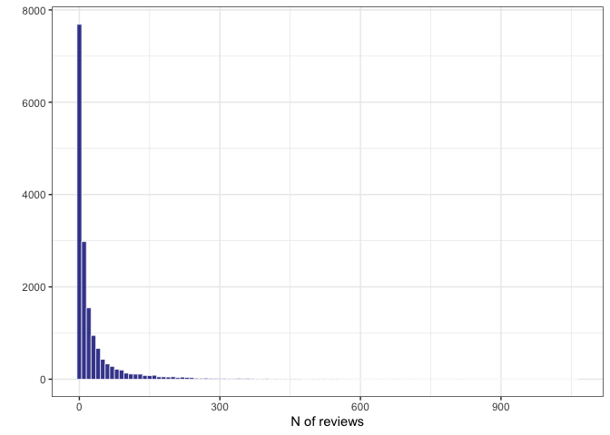

```r
## Number of reviews

ggplot(data, aes(n_number_of_reviews)) +
  geom_histogram(binwidth = 10, fill = 'navyblue', color = 'white', alpha = 0.8, size = 0.25) +
  ylab("") +
  xlab("N of reviews") +
  theme_bw()
```

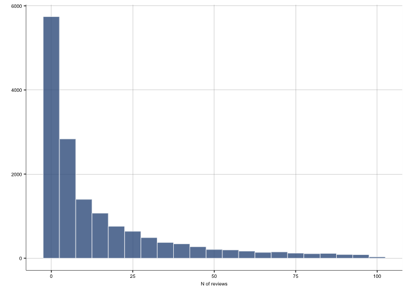

```r
nreview_plot <- data %>%
  filter(n_number_of_reviews <100)

ggplot(nreview_plot, aes(n_number_of_reviews)) +
  geom_histogram(binwidth = 5, fill = color[1], color = color.outline, alpha = 0.8, size = 0.25) +
  ylab("") +
  xlab("N of reviews") +
  theme_bg()
```

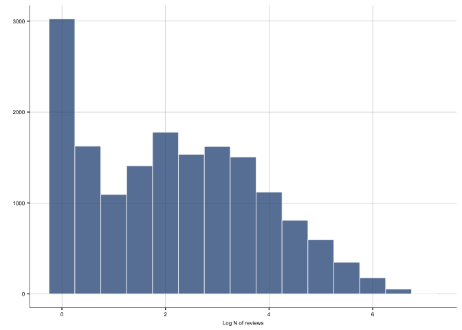

```r
# number of reviews: use logs as well
data <- data %>%
  mutate(ln_number_of_reviews = log(n_number_of_reviews+1))

ggplot(data, aes(ln_number_of_reviews)) +
  geom_histogram(binwidth = 0.5, fill = color[1], color = color.outline, alpha = 0.8, size = 0.25) +
  ylab("") +
  xlab("Log N of reviews") +
  theme_bg()
```

```r
# Pool num of reviews to 3 categories: none, 1-51 and >51
data <- data %>%
  mutate(f_number_of_reviews = cut(n_number_of_reviews, c(0,1,51,max(data$n_number_of_reviews)+1), labels=c(0,1,2), right = F))

data %>%
  group_by(f_number_of_reviews) %>%
  summarise(median_price = median(price), mean_price = mean(price) ,  n=n())
```

| f_number_of_reviews | median_price | mean_price | n |
| --- | --- | --- | --- |
| 0 | 120 | 179 | 3025 |
| 1 | 100 | 127 | 11037 |
| 2 | 87 | 103 | 2638 |

## Review scores rating

From the graph, most of the apartments have a high review score, but there is no clear relation with daily prices.

```r
## review score effect
data %>%
  group_by(review_scores_rating) %>%
  summarise(mean_price = mean(price), min_price= min(price), max_price = max(price), n = n())
```

| review_scores_rating | mean_price | min_price | max_price | n |
| --- | --- | --- | --- | --- |
| 0 | 144 | 23 | 500 | 160 |
| 1 | 130 | 40 | 601 | 48 |
| 1.5 | 80.7 | 64 | 100 | 3 |
| 1.67 | 71 | 71 | 71 | 1 |
| 2 | 129 | 50 | 500 | 40 |
| 2.25 | 77.3 | 51 | 121 | 3 |
| 2.33 | 175 | 175 | 175 | 1 |
| 2.4 | 73 | 73 | 73 | 1 |
| 2.43 | 139 | 139 | 139 | 1 |
| 2.5 | 86.6 | 27 | 165 | 17 |
| 2.6 | 93.3 | 58 | 136 | 3 |
| 2.67 | 99.2 | 69 | 133 | 6 |
| 2.75 | 97.4 | 53.3 | 143 | 3 |
| 2.8 | 107 | 58 | 133 | 3 |
| 2.83 | 77 | 77 | 77 | 1 |
| 2.86 | 72 | 72 | 72 | 1 |
| 2.91 | 66 | 66 | 66 | 1 |
| 3 | 135 | 25 | 680 | 132 |
| 3.07 | 125 | 125 | 125 | 1 |
| 3.08 | 113 | 113 | 113 | 1 |
| 3.13 | 113 | 113 | 113 | 1 |
| 3.15 | 113 | 113 | 113 | 1 |
| 3.17 | 119 | 58 | 215 | 5 |
| 3.18 | 105 | 80 | 130 | 2 |
| 3.2 | 108 | 48 | 170 | 8 |
| 3.25 | 134 | 30 | 555 | 12 |
| 3.27 | 462 | 462 | 462 | 1 |
| 3.29 | 67 | 67 | 67 | 1 |
| 3.3 | 107 | 81 | 133 | 2 |
| 3.33 | 125 | 31 | 300 | 34 |

[output cut: 150 more lines]

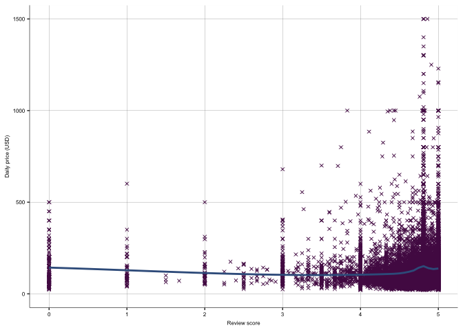

```r
ggplot(data = data, aes(x=review_scores_rating , y=price)) +
  geom_point(size=1.5, colour=color[3], shape=4) +
  ylim(0,1500)+
  xlim(0,5)+
  geom_smooth(method="loess", colour=color[1], se=F)+
  labs(x="Review score",y="Daily price (USD)")+
  theme_bg()
```

## Minimum nights

```r
# minimum nights
#not specified if only short stays

data %>%
  group_by(n_minimum_nights) %>%
  summarise(mean_price = mean(price), min_price= min(price), max_price = max(price), n = n())
```

| n_minimum_nights | mean_price | min_price | max_price | n |
| --- | --- | --- | --- | --- |
| 1 | 132 | 21 | 1.5e+03 | 6267 |
| 2 | 128 | 21 | 1.4e+03 | 5589 |
| 3 | 141 | 22 | 1.5e+03 | 2264 |
| 4 | 153 | 24 | 800 | 676 |
| 5 | 167 | 22 | 1.5e+03 | 540 |
| 6 | 145 | 30 | 800 | 150 |
| 7 | 123 | 21 | 1e+03 | 327 |
| 8 | 154 | 40 | 289 | 5 |
| 9 | 126 | 47 | 300 | 6 |
| 10 | 85.3 | 30 | 370 | 83 |
| 11 | 82 | 74 | 90 | 2 |
| 12 | 79.8 | 48 | 120 | 6 |
| 13 | 78.8 | 44 | 145 | 5 |
| 14 | 101 | 22 | 500 | 46 |
| 15 | 105 | 24 | 1e+03 | 88 |
| 16 | 61.5 | 50 | 73 | 2 |
| 19 | 47 | 47 | 47 | 1 |
| 20 | 83.6 | 28 | 298 | 41 |
| 21 | 108 | 30 | 550 | 17 |
| 22 | 85.5 | 81 | 90 | 2 |
| 24 | 62 | 62 | 62 | 1 |
| 25 | 107 | 38 | 430 | 11 |
| 27 | 80 | 59 | 121 | 3 |
| 28 | 98.5 | 32 | 280 | 46 |
| 29 | 118 | 41 | 800 | 80 |
| 30 | 127 | 25 | 1.35e+03 | 249 |
| 31 | 83.7 | 34 | 225 | 24 |
| 35 | 289 | 78 | 500 | 2 |
| 39 | 93 | 93 | 93 | 1 |
| 40 | 132 | 50 | 246 | 3 |
| 45 | 50 | 50 | 50 | 1 |
| 50 | 87.7 | 68 | 120 | 3 |
| 59 | 117 | 117 | 117 | 1 |
| 60 | 76.6 | 25 | 300 | 37 |
| 61 | 159 | 120 | 238 | 3 |
| 65 | 70 | 70 | 70 | 2 |
| 70 | 55 | 35 | 90 | 3 |
| 80 | 30 | 30 | 30 | 1 |
| 87 | 37 | 37 | 37 | 1 |
| 90 | 87.2 | 21 | 250 | 34 |
| 91 | 35 | 35 | 35 | 1 |
| 92 | 150 | 150 | 150 | 1 |
| 95 | 285 | 285 | 285 | 1 |
| 99 | 142 | 35 | 250 | 2 |
| 100 | 50 | 38 | 62 | 2 |
| 110 | 46 | 46 | 46 | 1 |
| 120 | 140 | 35 | 500 | 8 |
| 140 | 100 | 100 | 100 | 1 |
| 148 | 70 | 65 | 75 | 3 |
| 150 | 116 | 40 | 250 | 6 |
| 180 | 120 | 30 | 480 | 18 |
| 181 | 40 | 40 | 40 | 1 |
| 200 | 75 | 75 | 75 | 1 |
| 210 | 67 | 67 | 67 | 1 |
| 260 | 53 | 53 | 53 | 1 |
| 270 | 67 | 67 | 67 | 1 |
| 271 | 168 | 168 | 168 | 1 |
| 280 | 1e+03 | 1e+03 | 1e+03 | 1 |
| 299 | 80 | 80 | 80 | 1 |
| 300 | 242 | 35 | 800 | 4 |
| 356 | 80 | 80 | 80 | 1 |
| 360 | 100 | 100 | 100 | 1 |
| 365 | 144 | 24 | 500 | 12 |
| 500 | 35 | 35 | 35 | 1 |
| 600 | 65 | 65 | 65 | 1 |
| 720 | 200 | 200 | 200 | 1 |
| 1000 | 137 | 74 | 200 | 2 |
| 1124 | 30 | 30 | 30 | 1 |
| 1125 | 99 | 99 | 99 | 1 |

```r
data <- data %>%
  mutate(f_minimum_nights= cut(n_minimum_nights, c(1,2,3,7,max(data$n_minimum_nights)+1), labels=c(1,2,3,4), right = F))

data %>%
  group_by(f_minimum_nights) %>%
  summarise(mean_price = mean(price), min_price= min(price), max_price = max(price), n = n())
```

| f_minimum_nights | mean_price | min_price | max_price | n |
| --- | --- | --- | --- | --- |
| 1 | 132 | 21 | 1.5e+03 | 6267 |
| 2 | 128 | 21 | 1.4e+03 | 5589 |
| 3 | 147 | 22 | 1.5e+03 | 3630 |
| 4 | 113 | 21 | 1.35e+03 | 1214 |

# Models

My analysis starts by looking at potential interactions: 1. Minimum nights with children friendly amenities, presence of a gym, kitchen amenities, outdoor furniture 2. Room type with elevator, kitchen amenities, wardrobe, special view 3. Bathrooms with bathtub, hot tub, bathroom essentials, essentials From the bar charts, it can be seen that do not emerge very clear interactions

```r
#Look up min nights interactions
p1 <- price_diff_by_variables2(data, "f_minimum_nights", "d_babykit", "Minimum nights", "Children friendly")
p2 <- price_diff_by_variables2(data, "f_minimum_nights", "d_gym", "Minimum nights", "Gym")
p3 <- price_diff_by_variables2(data, "f_minimum_nights", "d_kitchenamenities", "Minimum nights", "Kitchen amenities")
p4 <- price_diff_by_variables2(data, "f_minimum_nights", "d_outdoorfurniture", "Minimum nights", "Outdoor furniture")
```

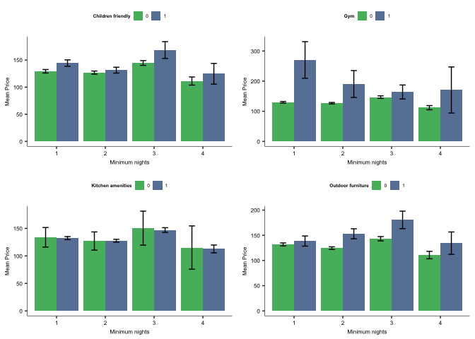

```r
g_interactions <- plot_grid(p1, p2, p3, p4, nrow=2, ncol=2)
g_interactions
```

```r
save_fig("interactions_min_nights",output,"large")
```

```r
#Look up room types interactions
p5 <- price_diff_by_variables2(data, "f_room_type", "d_elevator", "Room type", "Elevator")
p6 <- price_diff_by_variables2(data, "f_room_type", "d_kitchenamenities", "Room type", "Kitchen amenities")
p7 <- price_diff_by_variables2(data, "f_room_type", "d_wardrobe", "Room type", "Wardrobe")
p8 <- price_diff_by_variables2(data, "f_room_type", "d_specialview", "Room type", "Special view")
```

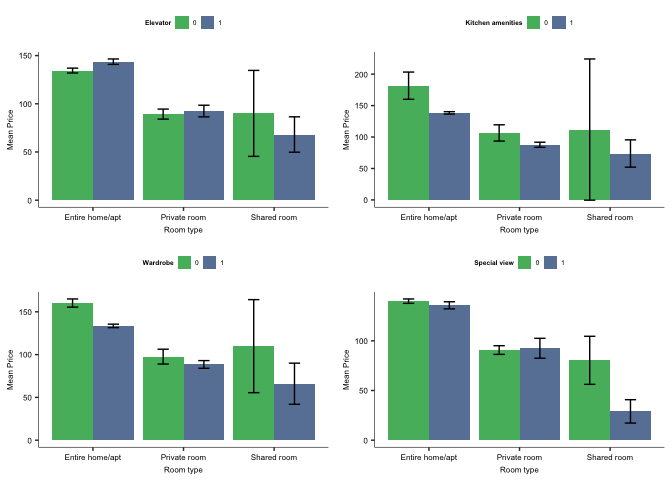

```r
g_interactions2 <- plot_grid(p5, p6, p7, p8, nrow=2, ncol=2)
g_interactions2
```

```r
save_fig("interactions_room_type",output,"large")
```

```r
#Look up bathrooms interactions
p9 <- price_diff_by_variables2(data, "n_bathrooms", "d_bathtub", "Bathrooms", "Bathtub")
p10 <- price_diff_by_variables2(data, "n_bathrooms", "d_hottub", "Bathrooms", "Hot tub")
p11 <- price_diff_by_variables2(data, "n_bathrooms", "d_bathroomessentials", "Bathrooms", "Bathroom essentials")
p12 <- price_diff_by_variables2(data, "n_bathrooms", "d_essentials", "Bathrooms", "Essentials")
```

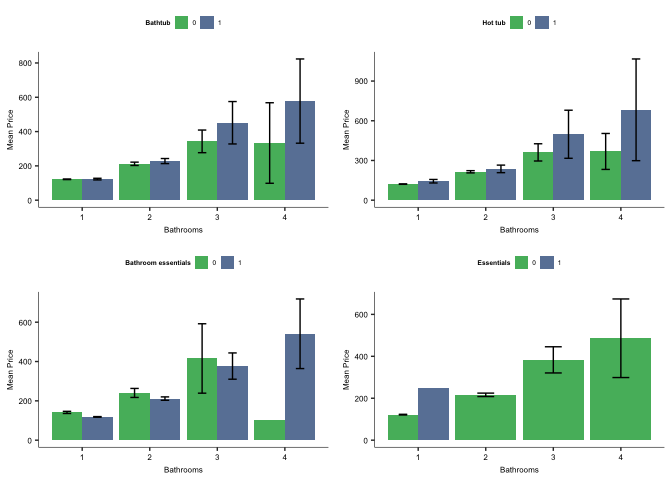

```r
g_interactions3 <- plot_grid(p9, p10, p11, p12, nrow=2, ncol=2)
g_interactions3
```

```r
save_fig("interactions_bathroom",output,"large")
```

## General setup

I group variables in basic variables, additional variables, review variables, and variables or higher order. These are the variables that I use in the analysis. Moreover, I put a d_ in front of all amenities dummies. Then, I randomly create: - Work set (data_work, 80% of the total data): where I will do the model building, the selection of the best model and the prediction; - Holdout set (data_holdout, 20% of the total data): part of the data for evaluating the prediction itself Finally, I create interactions following the graphs and interactions of variables that I believe are more relevant with the amenities.

```r
# Basic Variables
basic_lev  <- c("n_accommodates", "f_room_type", "f_municipio")
# Additional variables
basic_add <- c("n_beds", "n_bathrooms", "f_minimum_nights", "n_days_since", "flag_days_since")
reviews <- c("f_number_of_reviews","review_scores_rating", "flag_review_scores_rating")
# Higher orders
poly_lev <- c("n_accommodates2", "n_days_since2", "n_days_since3")

# Dummy variables: Extras -> collect all options and create dummies
amenities <-  grep("^d_.*", names(data), value = TRUE)


# Separate the Holdout set, and obtain the Working data

# create a holdout set (20% of observations)
smp_size <- floor(0.2 * nrow(data))

# Set the random number generator: It will make results reproducible
set.seed(20180123)

# create ids:
# 1) seq_len: generate regular sequences
# 2) sample: select random rows from a table
holdout_ids <- sample(seq_len(nrow(data)), size = smp_size)
data$holdout <- 0
data$holdout[holdout_ids] <- 1

#Hold-out set Set
data_holdout <- data %>% filter(holdout == 1)

#Working data set
data_work <- data %>% filter(holdout == 0)

#Interactions suggested by the graphs
X1 <- c("f_minimum_nights*(d_babykit+d_outdoorfurniture+d_gym)")
#Additional interactions
X2  <- c(paste0("(f_room_type+f_municipio+f_minimum_nights+n_bathrooms) * (",
                paste(amenities, collapse=" + "),")"))
```